# task 7

Paulius Kostickis

Tuesday, April 05, 2016

1. The function tsdisplay(data, plot.type=“scatter”) is useful for showing a time plot, ACF plot and lagged scatterplot on the same graph. Use it to produce plots of the following time series: bricksq, hsales, ibmclose Can you spot the effects of seasonality, cyclicity and trend?

### Bricksq duomenys

Duomenys tai - Australijos plytų gaminimas:

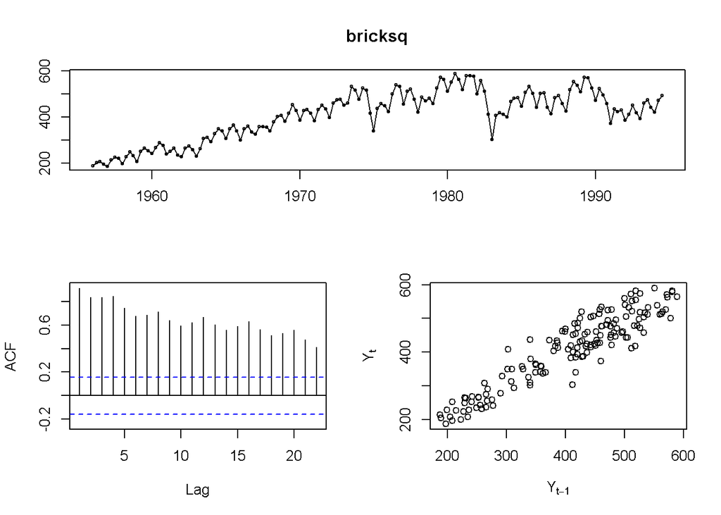

```r
tsdisplay(bricksq, plot.type="scatter")  #visų duomenų grafikas
```

Paėmus bricksq duomenis duomenis iki 1972, iš ACF grafiko matomas akivaizdus sezoniškumas, nes AFC kas 4 lag’us pasiekia piką. Kadangi matuotas ketvirčiais, praėjusių metų ketvirčiai geriausiai prognozuoja tuos pačius ketvirčius kitiem metam. Taip pat gęstantis AFC rodo trendo egzistavimą.

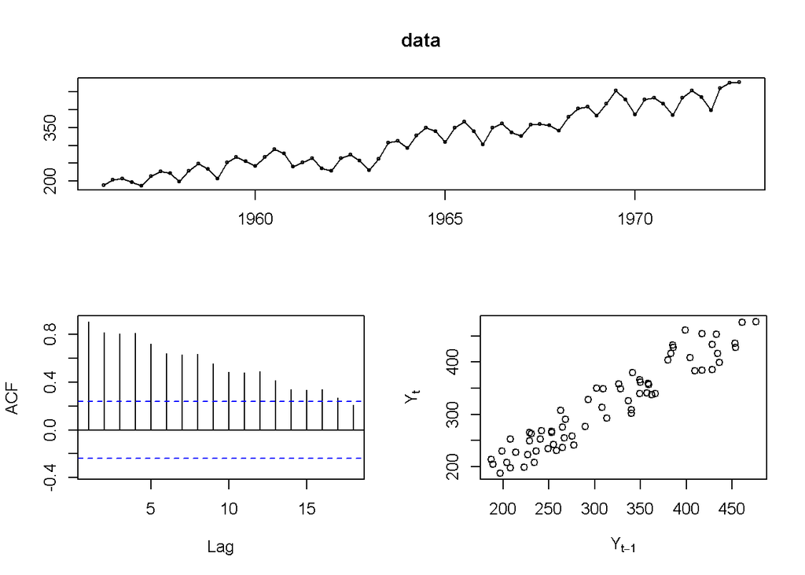

```r
data=window(bricksq,end=1972.99)            # iki 1973 duomenys
tsdisplay(data, plot.type="scatter")     # iki 1973 duomenų grafikas
```

Paėmus bricksq duomenis nuo 1973, iš AFC grafiko matome, kad kovariacija apsivertė - iš teigiamo tapo neigiama ir pasiekia AFC žemumą kas 4 lag’us. Taigi yra sezoniškumas, dingo trendas, tačiau matomi ciklai.

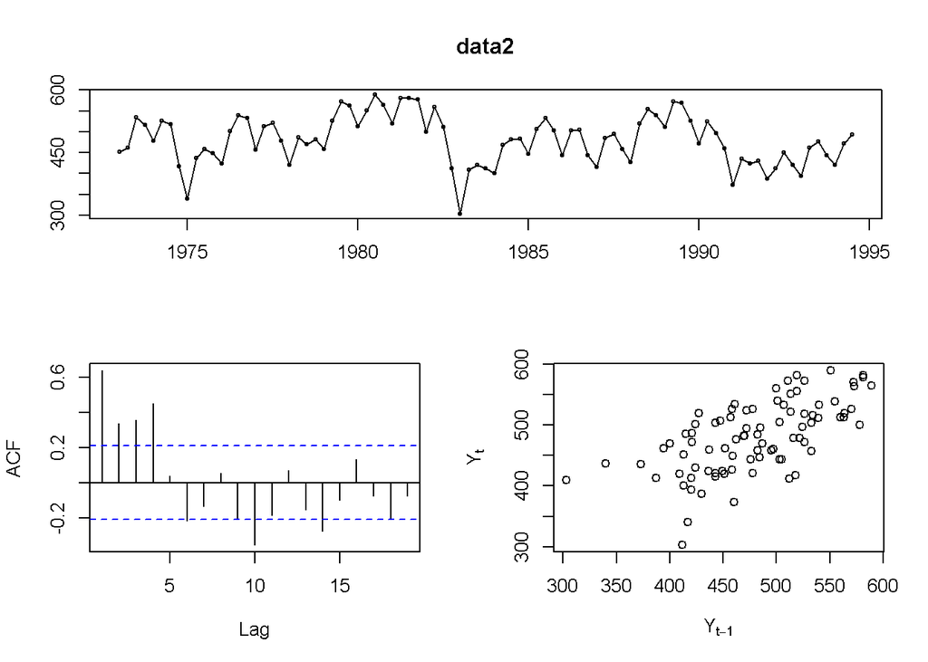

```r
data2=window(bricksq,start=1973)         #nuo 1973 duomenys
tsdisplay(data2, plot.type="scatter")    #nuo 1973 duomenų grafikas
```

### Hsales duomenys

Duomenys - JAV namų pardavimai. Yra sezoniškumas pagal AFC, nėra trendo, bet yra cikliškumas.

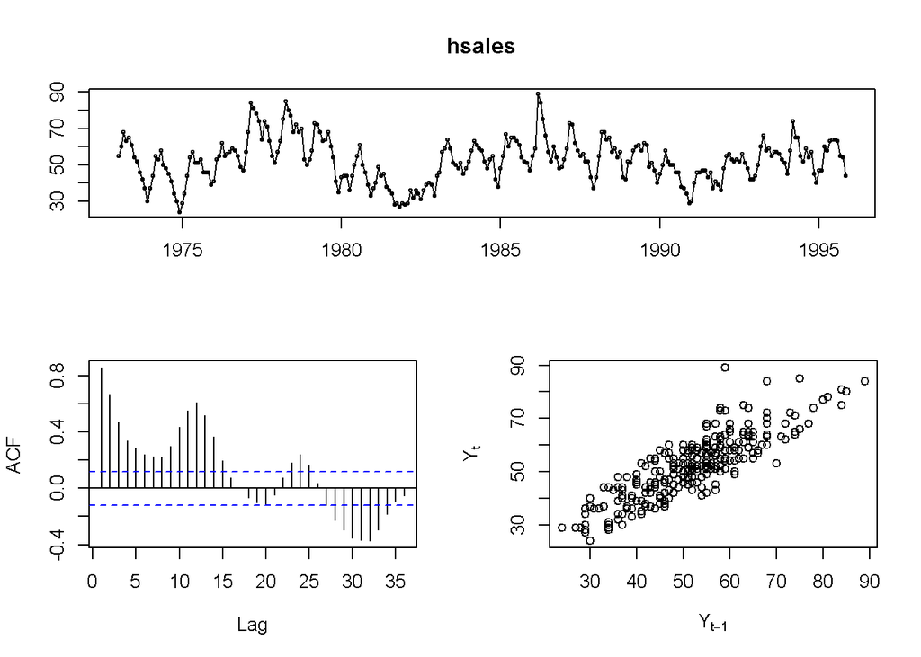

```r
tsdisplay(hsales, plot.type="scatter")   #visų duomenų grafikas
```

### Ibmclose duomenys

Duomenys - paskutinė IBM akcijų dienos kaina.

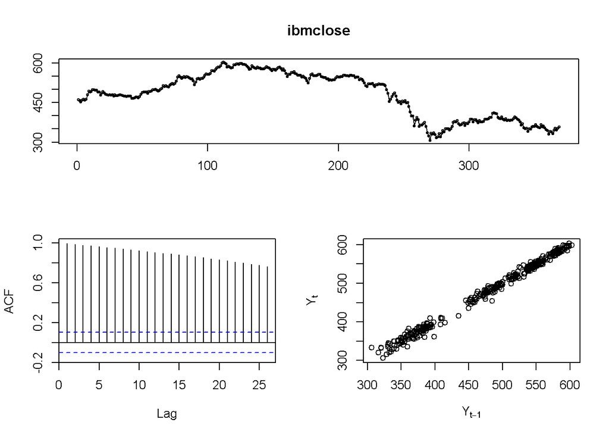

```r
tsdisplay(ibmclose, plot.type="scatter") #visų duomenų grafikas
```

Kadangi duomenys yra surinkti tik vienerių metų bėgyje, negalime nustatyti sezoniškumo ir cikliškumo. Tačiau matome, kad Y vienas su kitu koreliuoja, galime sakyti, kad grafikas yra random walk.